```r
# Find the project root by looking for the main project folders
find_project_root <- function(start = getwd()) {
  current <- normalizePath(start, mustWork = TRUE)

  repeat {
    required_dirs <- c("data", "notebooks", "results", "src")

    if (all(dir.exists(file.path(current, required_dirs)))) {
      return(current)
    }

    parent <- dirname(current)

    if (identical(parent, current)) {
      stop("Project root could not be found. Please check your folder structure.")
    }

    current <- parent
  }
}

# Project root
project_root <- find_project_root()

# Define project folders
data_raw_dir <- file.path(project_root, "data", "raw")
data_processed_dir <- file.path(project_root, "data", "processed")

figures_dir <- file.path(project_root, "results", "figures")
tables_dir <- file.path(project_root, "results", "tables")
models_dir <- file.path(project_root, "results", "models")

# Create folders if they do not already exist
dir.create(data_raw_dir, recursive = TRUE, showWarnings = FALSE)
dir.create(data_processed_dir, recursive = TRUE, showWarnings = FALSE)

dir.create(figures_dir, recursive = TRUE, showWarnings = FALSE)
dir.create(tables_dir, recursive = TRUE, showWarnings = FALSE)
dir.create(models_dir, recursive = TRUE, showWarnings = FALSE)

# Show paths for checking
data.frame(
  Folder = c(
    "Project root",
    "Raw data",
    "Processed data",
    "Figures",
    "Tables",
    "Models"
  ),
  Path = c(
    project_root,
    data_raw_dir,
    data_processed_dir,
    figures_dir,
    tables_dir,
    models_dir
  )
)
```

```
##           Folder
## 1   Project root
## 2       Raw data
## 3 Processed data
## 4        Figures
## 5         Tables
## 6         Models
##                                                                                                       Path
## 1                 C:/Users/Administrator/OneDrive/Desktop/FIT5145/Assessment3/5145 mental-health-detection
## 2        C:/Users/Administrator/OneDrive/Desktop/FIT5145/Assessment3/5145 mental-health-detection/data/raw
## 3  C:/Users/Administrator/OneDrive/Desktop/FIT5145/Assessment3/5145 mental-health-detection/data/processed
## 4 C:/Users/Administrator/OneDrive/Desktop/FIT5145/Assessment3/5145 mental-health-detection/results/figures
## 5  C:/Users/Administrator/OneDrive/Desktop/FIT5145/Assessment3/5145 mental-health-detection/results/tables
## 6  C:/Users/Administrator/OneDrive/Desktop/FIT5145/Assessment3/5145 mental-health-detection/results/models
```

```r
save_figure <- function(plot_object, file_name, width = 8, height = 5, dpi = 300) {
  ggsave(
    filename = file.path(figures_dir, file_name),
    plot = plot_object,
    width = width,
    height = height,
    dpi = dpi
  )
}
```

## 1 Introduction

This project aims to detect depression-related posts from Reddit using natural language processing and machine learning techniques.

## 2 Load Data

This section loads two Reddit mental health datasets: depression-related posts and ADHD-related posts. The depression dataset is treated as the target class, while the ADHD dataset is used as a comparison group.

```r
# Helper function to make file paths more reproducible
find_file <- function(filename) {
  candidate_paths <- c(
    filename,
    file.path("data", filename),
    file.path("..", "data", filename)
  )

  existing_paths <- candidate_paths[file.exists(candidate_paths)]

  if (length(existing_paths) == 0) {
    stop(paste("Cannot find file:", filename))
  }

  existing_paths[1]
}

# Load data
depression <- read.csv(find_file("depression.csv"), stringsAsFactors = FALSE)
adhd <- read.csv(find_file("adhd.csv"), stringsAsFactors = FALSE)

# Check dataset dimensions without displaying sensitive raw posts
data.frame(
  Dataset = c("Depression", "ADHD"),
  Rows = c(nrow(depression), nrow(adhd)),
  Columns = c(ncol(depression), ncol(adhd))
)
```

```
##      Dataset  Rows Columns
## 1 Depression 24031      10
## 2       ADHD 37109      10
```

## 3 Data Preprocessing

The raw datasets contain Reddit post titles, post bodies, metadata, and subreddit labels. For this project, the title and body fields are combined to create a single text field. Posts marked as `[removed]` or `[deleted]` are excluded because they do not contain meaningful textual information for analysis.

```r
# Check required columns
required_columns <- c("title", "body")

if (!all(required_columns %in% names(depression))) {
  stop("The depression dataset does not contain the required columns: title and body.")
}

if (!all(required_columns %in% names(adhd))) {
  stop("The ADHD dataset does not contain the required columns: title and body.")
}

# Create text and label fields
depression$text_raw <- paste(
  ifelse(is.na(depression$title), "", depression$title),
  ifelse(is.na(depression$body), "", depression$body)
)

adhd$text_raw <- paste(
  ifelse(is.na(adhd$title), "", adhd$title),
  ifelse(is.na(adhd$body), "", adhd$body)
)

# Label: 1 = depression-related posts, 0 = ADHD-related comparison posts
depression$label <- 1
adhd$label <- 0

# Keep only variables needed for analysis
depression_selected <- depression[, c("text_raw", "label")]
adhd_selected <- adhd[, c("text_raw", "label")]

# Merge datasets
data_raw <- rbind(depression_selected, adhd_selected)

# Record initial dataset size
initial_n <- nrow(data_raw)

# Identify invalid posts
removed_or_deleted <- grepl("\\[removed\\]|\\[deleted\\]", data_raw$text_raw, ignore.case = TRUE)
empty_text <- is.na(data_raw$text_raw) | trimws(data_raw$text_raw) == ""

# Remove invalid posts
data_clean <- data_raw[!removed_or_deleted & !empty_text, ]

# Create a cleaning summary table
cleaning_summary <- data.frame(
  Stage = c(
    "Initial merged dataset",
    "Removed/deleted posts",
    "Empty or missing text",
    "Final cleaned dataset"
  ),
  Count = c(
    initial_n,
    sum(removed_or_deleted),
    sum(empty_text),
    nrow(data_clean)
  )
)

cleaning_summary
```

```
##                    Stage Count
## 1 Initial merged dataset 61140
## 2  Removed/deleted posts 26858
## 3  Empty or missing text     0
## 4  Final cleaned dataset 34282
```

The cleaning process removes posts that do not contain meaningful text. This is important because deleted or removed Reddit posts would introduce noise into word frequency analysis and machine learning models.

## 4 Exploratory Data Analysis

This section examines the basic characteristics of the cleaned dataset, including class distribution and text length. These exploratory results help assess whether the dataset is suitable for text classification.

### 4.1 Class Distribution

```r
library(ggplot2)

# Convert numeric labels into meaningful class names
data_clean$class <- ifelse(
  data_clean$label == 1,
  "Depression-related posts",
  "ADHD comparison posts"
)

# Create class distribution summary
class_distribution <- as.data.frame(table(data_clean$class))
colnames(class_distribution) <- c("Class", "Count")

class_distribution$Percentage <- round(
  class_distribution$Count / sum(class_distribution$Count) * 100,
  2
)

class_distribution
```

```
##                      Class Count Percentage
## 1    ADHD comparison posts 20398       59.5
## 2 Depression-related posts 13884       40.5
```

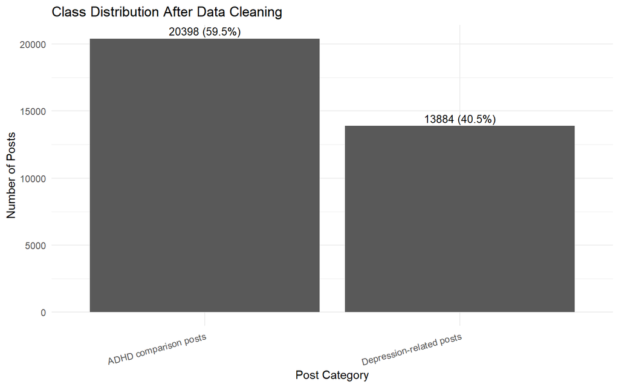

```r
p_class_distribution <- ggplot(class_distribution, aes(x = Class, y = Count)) +
  geom_col() +
  geom_text(
    aes(label = paste0(Count, " (", Percentage, "%)")),
    vjust = -0.4,
    size = 3.5
  ) +
  labs(
    title = "Class Distribution After Data Cleaning",
    x = "Post Category",
    y = "Number of Posts"
  ) +
  theme_minimal() +
  theme(
    axis.text.x = element_text(angle = 15, hjust = 1)
  )

p_class_distribution
```

```r
save_figure(
  p_class_distribution,
  "class_distribution.png",
  width = 8,
  height = 5
)
```

The cleaned dataset contains posts from both depression-related and ADHD-related Reddit communities. The ADHD posts are used as a comparison group, while depression-related posts are treated as the target class. The class distribution is moderately imbalanced, so model evaluation should consider not only accuracy but also precision, recall, and F1-score.

### 4.2 Text Length Distribution

Text length is an important characteristic of social media data because very short posts may contain limited linguistic information, while very long posts may introduce extreme values and noise. This section compares the word counts of ADHD comparison posts and depression-related posts.

```r
# Calculate text length
data_clean$char_count <- nchar(data_clean$text_raw)

data_clean$word_count <- sapply(
  strsplit(trimws(data_clean$text_raw), "\\s+"),
  length
)

# Summary statistics by class
text_length_summary <- do.call(
  rbind,
  lapply(split(data_clean$word_count, data_clean$class), function(x) {
    data.frame(
      Count = length(x),
      Min = min(x),
      Q1 = as.numeric(quantile(x, 0.25)),
      Median = median(x),
      Mean = round(mean(x), 2),
      Q3 = as.numeric(quantile(x, 0.75)),
      Max = max(x)
    )
  })
)

text_length_summary$Class <- rownames(text_length_summary)
rownames(text_length_summary) <- NULL

text_length_summary <- text_length_summary[
  , c("Class", "Count", "Min", "Q1", "Median", "Mean", "Q3", "Max")
]

text_length_summary
```

```
##                      Class Count Min  Q1 Median   Mean  Q3  Max
## 1    ADHD comparison posts 20398  14 105    157 210.87 252 6699
## 2 Depression-related posts 13884   2  63    123 179.61 221 4219
```

```r
# Ensure required fields exist before saving
if (!"class" %in% names(data_clean)) {
  data_clean$class <- ifelse(
    data_clean$label == 1,
    "Depression-related posts",
    "ADHD comparison posts"
  )
}

if (!"char_count" %in% names(data_clean)) {
  data_clean$char_count <- nchar(data_clean$text_raw)
}

if (!"word_count" %in% names(data_clean)) {
  data_clean$word_count <- sapply(
    strsplit(trimws(data_clean$text_raw), "\\s+"),
    length
  )
}

# Save the full cleaned dataset locally
write.csv(
  data_clean,
  file.path(data_processed_dir, "data_clean_full.csv"),
  row.names = FALSE
)

# Save a privacy-safer metadata version for GitHub
safe_columns <- intersect(
  c("label", "class", "char_count", "word_count"),
  names(data_clean)
)

data_clean_safe <- data_clean[, safe_columns]

write.csv(
  data_clean_safe,
  file.path(data_processed_dir, "data_clean_safe_metadata.csv"),
  row.names = FALSE
)

data.frame(
  File = c(
    "data_clean_full.csv",
    "data_clean_safe_metadata.csv"
  ),
  Rows = c(
    nrow(data_clean),
    nrow(data_clean_safe)
  ),
  Columns = c(
    ncol(data_clean),
    ncol(data_clean_safe)
  )
)
```

```
##                           File  Rows Columns
## 1          data_clean_full.csv 34282       5
## 2 data_clean_safe_metadata.csv 34282       4
```

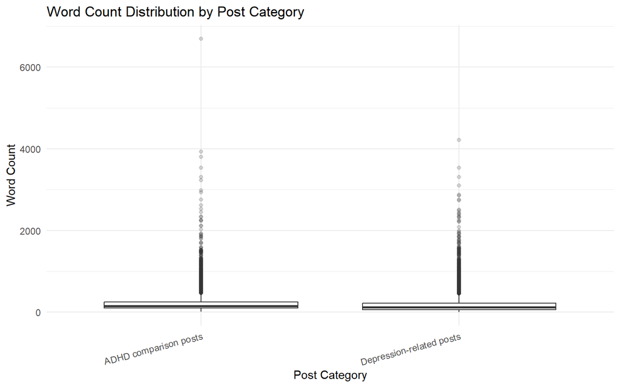

```r
ggplot(data_clean, aes(x = class, y = word_count)) +
  geom_boxplot(outlier.alpha = 0.2) +
  labs(
    title = "Word Count Distribution by Post Category",
    x = "Post Category",
    y = "Word Count"
  ) +
  theme_minimal() +
  theme(
    axis.text.x = element_text(angle = 15, hjust = 1)
  )
```

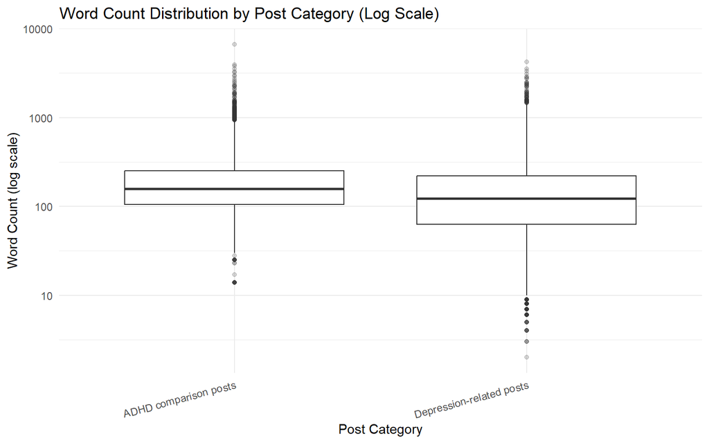

```r
p_text_length_log <- ggplot(data_clean, aes(x = class, y = word_count)) +
  geom_boxplot(outlier.alpha = 0.2) +
  scale_y_log10() +
  labs(
    title = "Word Count Distribution by Post Category (Log Scale)",
    x = "Post Category",
    y = "Word Count (log scale)"
  ) +
  theme_minimal() +
  theme(
    axis.text.x = element_text(angle = 15, hjust = 1)
  )

p_text_length_log
```

```r
save_figure(
  p_text_length_log,
  "text_length_log_boxplot.png",
  width = 8,
  height = 5
)
```

The word count distribution helps assess whether the two post categories differ in writing style or post length. Because social media text often contains extreme values, the log-scale plot provides a clearer view of the central distribution while still preserving the effect of longer posts.

### 4.3 Word Frequency Analysis by Class

Word frequency analysis helps identify common linguistic patterns in each category. To make the results more informative, this section removes standard stop words, common contractions, numbers, and obvious label-specific words such as “adhd” and “depression”. This reduces the risk that the analysis is dominated by direct subreddit labels rather than broader linguistic patterns.

```r
library(dplyr)
library(tidytext)
library(stringr)

# Create a document ID for tokenisation
data_clean$doc_id <- seq_len(nrow(data_clean))

# Custom stop words for Reddit-style text and obvious label words
custom_stop_words <- data.frame(
  word = c(
    "im", "ive", "id", "ill", "youre", "youve", "youll",
    "dont", "doesnt", "didnt", "cant", "couldnt", "wouldnt",
    "shouldnt", "isnt", "arent", "wasnt", "werent",
    "thats", "theres", "whats", "wont", "itll", "its",
    "adhd", "depression", "depressed", "depressive"
  ),
  lexicon = "custom"
)

all_stop_words <- bind_rows(stop_words, custom_stop_words)

# Prepare text for tokenisation
word_data <- data_clean %>%
  select(doc_id, class, text_raw) %>%
  mutate(
    text_for_words = str_to_lower(text_raw),
    text_for_words = str_replace_all(text_for_words, "[’‘`]", "'")
  ) %>%
  unnest_tokens(word, text_for_words) %>%
  mutate(
    word = str_replace_all(word, "[^a-z]", "")
  ) %>%
  filter(word != "") %>%
  filter(!str_detect(word, "^[0-9]+$")) %>%
  filter(str_length(word) > 2) %>%
  anti_join(all_stop_words, by = "word")

# Count word frequency by class
word_frequency <- word_data %>%
  count(class, word, sort = TRUE)

head(word_frequency, 10)
```

```
##                       class   word     n
## 1     ADHD comparison posts   feel 16939
## 2  Depression-related posts   feel 16880
## 3     ADHD comparison posts   time 15415
## 4  Depression-related posts   life 11150
## 5     ADHD comparison posts    day  9536
## 6     ADHD comparison posts people  8957
## 7     ADHD comparison posts   life  8620
## 8  Depression-related posts   time  8149
## 9     ADHD comparison posts   meds  7208
## 10 Depression-related posts people  7191
```

```r
top_words_by_class <- word_frequency %>%
  group_by(class) %>%
  slice_max(n, n = 20, with_ties = FALSE) %>%
  ungroup()

top_words_by_class
```

```
## # A tibble: 40 × 3
##    class                 word           n
##    <chr>                 <chr>      <int>
##  1 ADHD comparison posts feel       16939
##  2 ADHD comparison posts time       15415
##  3 ADHD comparison posts day         9536
##  4 ADHD comparison posts people      8957
##  5 ADHD comparison posts life        8620
##  6 ADHD comparison posts meds        7208
##  7 ADHD comparison posts medication  7105
##  8 ADHD comparison posts diagnosed   6514
##  9 ADHD comparison posts lot         5788
## 10 ADHD comparison posts school      5781
## # ℹ 30 more rows
```

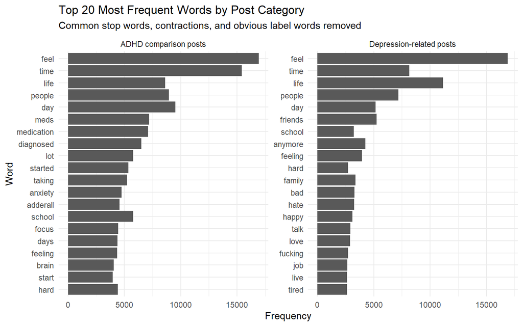

```r
p_top_words <- ggplot(top_words_by_class, aes(x = reorder(word, n), y = n)) +
  geom_col() +
  coord_flip() +
  facet_wrap(~ class, scales = "free_y") +
  labs(
    title = "Top 20 Most Frequent Words by Post Category",
    subtitle = "Common stop words, contractions, and obvious label words removed",
    x = "Word",
    y = "Frequency"
  ) +
  theme_minimal()

p_top_words
```

```r
save_figure(
  p_top_words,
  "top_words_by_class.png",
  width = 9,
  height = 5.5
)
```

After removing common stop words, contractions, and obvious label words, the remaining terms provide a clearer view of broader linguistic patterns in the two post categories. These patterns are useful for exploratory understanding, but raw frequency alone is not sufficient for classification because it does not account for how distinctive a word is across categories.

### 4.4 TF-IDF Comparison by Class

Raw word frequency shows common words in each class, but it does not show how distinctive a word is within individual posts. To obtain a more meaningful comparison, this section calculates TF-IDF at the individual post level and then summarises the average TF-IDF value of each word by post category.

Because the dataset contains sensitive mental health-related language, offensive, highly sensitive, and unclear display terms are removed from the visualisation. The aim is to support responsible reporting while still showing interpretable linguistic patterns.

```r
# Count words within each individual post
doc_word_counts <- word_data %>%
  count(doc_id, class, word, name = "n")

# Calculate TF-IDF at the post level
doc_tfidf <- doc_word_counts %>%
  bind_tf_idf(term = word, document = doc_id, n = n)

# Summarise TF-IDF by class and word
tfidf_by_class <- doc_tfidf %>%
  group_by(class, word) %>%
  summarise(
    total_count = sum(n),
    doc_count = n_distinct(doc_id),
    mean_tfidf = mean(tf_idf),
    .groups = "drop"
  )
```

```r
# Terms removed only from the displayed plot to avoid showing highly sensitive,
# offensive, personal-name-like, or contextually unclear terms in the final visualisation.
sensitive_display_terms <- c(
  "raped", "slut", "retard", "incel", "chubby",
  "fucking", "fuck", "cunts", "shit",
  "weed", "druggy",
  "slit", "noose",
  "abortion",
  "debbie", "katie", "kathy", "gabe", "manzo", "pero",
  "bumble", "parfait",
  "homoeopathy"
)

# Create a presentation-safe version.
# Minimum count thresholds reduce the influence of rare or unclear terms.
tfidf_words_safe <- tfidf_by_class %>%
  filter(total_count >= 100) %>%
  filter(doc_count >= 20) %>%
  filter(!word %in% sensitive_display_terms)

top_tfidf_words_safe <- tfidf_words_safe %>%
  group_by(class) %>%
  slice_max(mean_tfidf, n = 20, with_ties = FALSE) %>%
  ungroup()

top_tfidf_words_safe
```

```
## # A tibble: 40 × 5
##    class                 word       total_count doc_count mean_tfidf
##    <chr>                 <chr>            <int>     <int>      <dbl>
##  1 ADHD comparison posts kaiser             109        47      0.320
##  2 ADHD comparison posts tics               109        59      0.271
##  3 ADHD comparison posts focalin            173       103      0.239
##  4 ADHD comparison posts guanfacine         105        68      0.226
##  5 ADHD comparison posts blah               105        44      0.215
##  6 ADHD comparison posts cerebral           104        66      0.208
##  7 ADHD comparison posts straterra          149        92      0.205
##  8 ADHD comparison posts thread             152       139      0.203
##  9 ADHD comparison posts dexedrine          201       114      0.199
## 10 ADHD comparison posts coach              135        90      0.195
## # ℹ 30 more rows
```

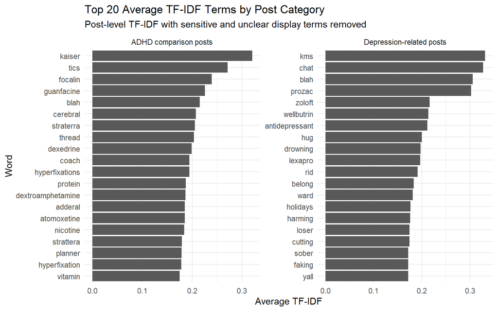

```r
p_tfidf <- ggplot(top_tfidf_words_safe, aes(
  x = reorder_within(word, mean_tfidf, class),
  y = mean_tfidf
)) +
  geom_col() +
  coord_flip() +
  facet_wrap(~ class, scales = "free") +
  scale_x_reordered() +
  labs(
    title = "Top 20 Average TF-IDF Terms by Post Category",
    subtitle = "Post-level TF-IDF with sensitive and unclear display terms removed",
    x = "Word",
    y = "Average TF-IDF"
  ) +
  theme_minimal()

p_tfidf
```

```r
save_figure(
  p_tfidf,
  "tfidf_terms_by_class.png",
  width = 9,
  height = 5.5
)
```

Post-level TF-IDF provides a more meaningful comparison than class-level TF-IDF because it treats each Reddit post as an individual document. This makes it easier to identify terms that are distinctive within posts from each category. ADHD comparison posts are expected to show terms related to medication, attention, diagnosis, and treatment experience, while depression-related posts are expected to show terms associated with emotional distress, social vulnerability, and negative life experiences.

## 5 Feature Engineering for Text Classification

This section converts cleaned Reddit text into numerical features for machine learning. A Document-Term Matrix (DTM) is used to represent each post using word-frequency features. The train-test split is created before finalising the vocabulary, so the test set is transformed using only terms learned from the training data. This helps reduce data leakage.

```r
library(tm)
library(SnowballC)

set.seed(5145)

# Prepare modelling data
model_data <- data_clean[, c("text_raw", "label", "class", "word_count")]

# Stratified train-test split
train_indices <- unlist(
  tapply(seq_len(nrow(model_data)), model_data$label, function(idx) {
    sample(idx, size = floor(0.8 * length(idx)))
  })
)

train_data <- model_data[train_indices, ]
test_data <- model_data[-train_indices, ]

# Text cleaning function for modelling
clean_corpus <- function(text_vector) {
  corpus <- VCorpus(VectorSource(text_vector))

  corpus <- tm_map(corpus, content_transformer(tolower))

  corpus <- tm_map(corpus, content_transformer(function(x) {
    gsub("[’‘`]", "'", x)
  }))

  corpus <- tm_map(corpus, removePunctuation)
  corpus <- tm_map(corpus, removeNumbers)

  # Remove standard stop words and direct label-related terms
  modelling_stop_words <- c(
    stopwords("english"),
    "adhd", "depression", "depressed", "depressive"
  )

  corpus <- tm_map(corpus, removeWords, modelling_stop_words)
  corpus <- tm_map(corpus, stemDocument)
  corpus <- tm_map(corpus, stripWhitespace)

  corpus
}

# Create training corpus and DTM
train_corpus <- clean_corpus(train_data$text_raw)

train_dtm <- DocumentTermMatrix(
  train_corpus,
  control = list(wordLengths = c(3, Inf))
)

# Remove sparse terms to reduce noise and computational complexity
train_dtm <- removeSparseTerms(train_dtm, 0.99)

# Use the training vocabulary as the dictionary for the test set
dtm_dictionary <- Terms(train_dtm)

test_corpus <- clean_corpus(test_data$text_raw)

test_dtm <- DocumentTermMatrix(
  test_corpus,
  control = list(dictionary = dtm_dictionary)
)

# Convert DTM objects to data frames
train_matrix <- as.data.frame(as.matrix(train_dtm))
test_matrix <- as.data.frame(as.matrix(test_dtm))

# Make feature names syntactically valid for modelling
feature_names <- make.names(colnames(train_matrix), unique = TRUE)
colnames(train_matrix) <- feature_names
colnames(test_matrix) <- feature_names

# Add outcome labels
train_matrix$label <- factor(
  train_data$label,
  levels = c(0, 1),
  labels = c("ADHD", "Depression")
)

test_matrix$label <- factor(
  test_data$label,
  levels = c(0, 1),
  labels = c("ADHD", "Depression")
)

# Create numeric labels for later evaluation
test_actual_numeric <- ifelse(test_matrix$label == "Depression", 1, 0)

# Summarise the feature engineering output
feature_summary <- data.frame(
  Item = c(
    "Training posts",
    "Testing posts",
    "Number of DTM features",
    "Training ADHD posts",
    "Training depression-related posts",
    "Testing ADHD posts",
    "Testing depression-related posts"
  ),
  Value = c(
    nrow(train_matrix),
    nrow(test_matrix),
    ncol(train_matrix) - 1,
    sum(train_matrix$label == "ADHD"),
    sum(train_matrix$label == "Depression"),
    sum(test_matrix$label == "ADHD"),
    sum(test_matrix$label == "Depression")
  )
)

feature_summary
```

```
##                                Item Value
## 1                    Training posts 27425
## 2                     Testing posts  6857
## 3            Number of DTM features  1095
## 4               Training ADHD posts 16318
## 5 Training depression-related posts 11107
## 6                Testing ADHD posts  4080
## 7  Testing depression-related posts  2777
```

The DTM representation transforms unstructured Reddit text into structured word-frequency features. Sparse terms are removed to reduce noise, improve computational efficiency, and make the models easier to interpret. Direct label-related words such as “adhd” and “depression” are removed to reduce the risk that the model relies only on obvious category names.

## 6 Model Development

This section trains two supervised text classification models: Logistic Regression and Naive Bayes. Logistic Regression is used as the main interpretable model because its coefficients can later be examined to understand which terms contribute to depression-related classification. Naive Bayes is used as a baseline model because it is commonly applied to text classification tasks.

```r
library(e1071)
library(pROC)

# Separate predictors and labels
train_x <- train_matrix[, setdiff(names(train_matrix), "label")]
test_x <- test_matrix[, setdiff(names(test_matrix), "label")]

train_y <- train_matrix$label
test_y <- test_matrix$label

# Logistic Regression model
logistic_model <- glm(
  label ~ .,
  data = train_matrix,
  family = binomial
)

# Predicted probabilities for the Depression class
logistic_prob <- predict(
  logistic_model,
  newdata = test_matrix,
  type = "response"
)

logistic_pred <- ifelse(logistic_prob >= 0.5, "Depression", "ADHD")
logistic_pred <- factor(logistic_pred, levels = c("ADHD", "Depression"))

# Naive Bayes model
nb_model <- naiveBayes(
  x = train_x,
  y = train_y
)

nb_pred <- predict(
  nb_model,
  newdata = test_x,
  type = "class"
)

nb_prob <- predict(
  nb_model,
  newdata = test_x,
  type = "raw"
)[, "Depression"]
```

Both models are trained using the same DTM features and the same train-test split. This makes their performance directly comparable.

## 7 Model Evaluation

This section evaluates model performance using accuracy, precision, recall, F1-score, confusion matrix, ROC curve, and AUC. Since this project focuses on early-risk identification, recall is particularly important because false negatives may represent depression-related posts that are missed by the model.

```r
# Evaluation function
evaluate_model <- function(actual, predicted, positive_class = "Depression") {
  actual <- factor(actual, levels = c("ADHD", "Depression"))
  predicted <- factor(predicted, levels = c("ADHD", "Depression"))

  cm <- table(Predicted = predicted, Actual = actual)

  tp <- cm[positive_class, positive_class]
  fp <- sum(cm[positive_class, ]) - tp
  fn <- sum(cm[, positive_class]) - tp
  tn <- sum(cm) - tp - fp - fn

  accuracy <- (tp + tn) / sum(cm)
  precision <- tp / (tp + fp)
  recall <- tp / (tp + fn)
  f1 <- 2 * precision * recall / (precision + recall)

  list(
    confusion_matrix = cm,
    metrics = data.frame(
      Accuracy = round(accuracy, 4),
      Precision = round(precision, 4),
      Recall = round(recall, 4),
      F1 = round(f1, 4)
    )
  )
}

# Evaluate models
logistic_eval <- evaluate_model(test_y, logistic_pred)
nb_eval <- evaluate_model(test_y, nb_pred)

logistic_eval$metrics
```

```
##   Accuracy Precision Recall     F1
## 1   0.9024    0.8714 0.8905 0.8809
```

```r
nb_eval$metrics
```

```
##   Accuracy Precision Recall     F1
## 1    0.768    0.6534 0.9096 0.7605
```

```r
logistic_eval$confusion_matrix
```

```
##             Actual
## Predicted    ADHD Depression
##   ADHD       3715        304
##   Depression  365       2473
```

```r
nb_eval$confusion_matrix
```

```
##             Actual
## Predicted    ADHD Depression
##   ADHD       2740        251
##   Depression 1340       2526
```

```r
model_comparison <- rbind(
  data.frame(Model = "Logistic Regression", logistic_eval$metrics),
  data.frame(Model = "Naive Bayes", nb_eval$metrics)
)

model_comparison
```

```
##                 Model Accuracy Precision Recall     F1
## 1 Logistic Regression   0.9024    0.8714 0.8905 0.8809
## 2         Naive Bayes   0.7680    0.6534 0.9096 0.7605
```

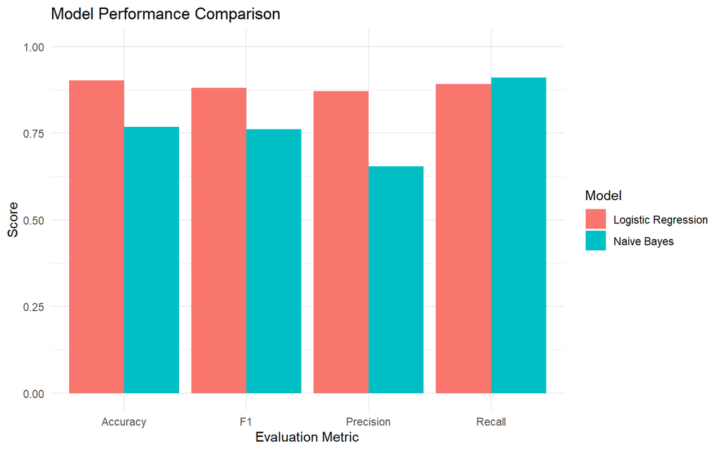

```r
model_comparison_long <- model_comparison %>%
  tidyr::pivot_longer(
    cols = c("Accuracy", "Precision", "Recall", "F1"),
    names_to = "Metric",
    values_to = "Value"
  )

p_model_comparison <- ggplot(model_comparison_long, aes(x = Metric, y = Value, fill = Model)) +
  geom_col(position = "dodge") +
  ylim(0, 1) +
  labs(
    title = "Model Performance Comparison",
    x = "Evaluation Metric",
    y = "Score"
  ) +
  theme_minimal()

p_model_comparison
```

```r
save_figure(
  p_model_comparison,
  "model_performance_comparison.png",
  width = 8,
  height = 5
)
```

The model comparison evaluates whether interpretable machine learning can distinguish depression-related posts from ADHD comparison posts. Accuracy alone is not sufficient for this project because the cost of false negatives may be higher in an early-risk triage setting.

### 7.1 ROC and AUC

```r
# Convert actual labels to binary values for ROC analysis
test_y_binary <- ifelse(test_y == "Depression", 1, 0)

# ROC curves
logistic_roc <- roc(test_y_binary, logistic_prob)
nb_roc <- roc(test_y_binary, nb_prob)

auc_summary <- data.frame(
  Model = c("Logistic Regression", "Naive Bayes"),
  AUC = c(
    round(as.numeric(auc(logistic_roc)), 4),
    round(as.numeric(auc(nb_roc)), 4)
  )
)

auc_summary
```

```
##                 Model    AUC
## 1 Logistic Regression 0.9577
## 2         Naive Bayes 0.8248
```

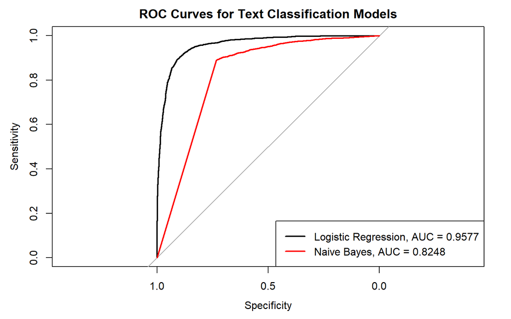

```r
draw_roc_plot <- function() {
  plot(
    logistic_roc,
    col = "black",
    lwd = 2,
    main = "ROC Curves for Text Classification Models"
  )

  lines(
    nb_roc,
    col = "red",
    lwd = 2
  )

  legend(
    "bottomright",
    legend = c(
      paste0("Logistic Regression, AUC = ", auc_summary$AUC[1]),
      paste0("Naive Bayes, AUC = ", auc_summary$AUC[2])
    ),
    col = c("black", "red"),
    lwd = 2
  )
}

# Display in HTML
draw_roc_plot()
```

```r
# Save to results/figures
png(
  filename = file.path(figures_dir, "roc_curves.png"),
  width = 2400,
  height = 1600,
  res = 300
)

draw_roc_plot()

dev.off()
```

ROC-AUC evaluates the model’s ability to separate depression-related posts from ADHD comparison posts across different classification thresholds. A higher AUC indicates stronger discrimination ability.

## 8 Model Interpretability

Logistic Regression is used as the main interpretable model because each coefficient indicates how strongly a term contributes to the prediction. Positive coefficients increase the log-odds of a post being classified as depression-related, while negative coefficients increase the likelihood of being classified as an ADHD comparison post.

```r
# Extract logistic regression coefficients
coef_values <- coef(logistic_model)

coef_df <- data.frame(
  term = names(coef_values),
  coefficient = as.numeric(coef_values)
)

# Remove intercept and non-finite values
coef_df <- coef_df %>%
  filter(term != "(Intercept)") %>%
  filter(is.finite(coefficient)) %>%
  mutate(
    odds_ratio = exp(coefficient),
    direction = ifelse(
      coefficient > 0,
      "More associated with Depression-related posts",
      "More associated with ADHD comparison posts"
    )
  )

# Top positive and negative coefficients
top_depression_terms <- coef_df %>%
  arrange(desc(coefficient)) %>%
  slice_head(n = 20)

top_adhd_terms <- coef_df %>%
  arrange(coefficient) %>%
  slice_head(n = 20)

top_depression_terms
```

```
##           term coefficient odds_ratio
## 1       suicid   2.7004621  14.886609
## 2      depress   1.5815161   4.862322
## 3       hospit   1.5021124   4.491166
## 4  antidepress   1.3452491   3.839143
## 5         kill   1.3056593   3.690121
## 6         dark   1.2974081   3.659799
## 7       episod   1.0868982   2.965063
## 8         numb   1.0214680   2.777269
## 9         dead   0.9766088   2.655436
## 10         die   0.9373814   2.553287
## 11        weak   0.9319404   2.539432
## 12   disappear   0.9158167   2.498815
## 13   worthless   0.8965280   2.451078
## 14       smile   0.8645318   2.373894
```

[output cut: 27 more lines]

```r
top_adhd_terms
```

```
##          term coefficient   odds_ratio
## 1  hyperfocus  -19.652390 2.917935e-09
## 2    concerta  -17.330360 2.975227e-08
## 3   strattera  -15.997436 1.128241e-07
## 4      vyvans   -5.084224 6.193692e-03
## 5      execut   -3.323600 3.602293e-02
## 6     ritalin   -3.071694 4.634260e-02
## 7     adderal   -2.969507 5.132859e-02
## 8    inattent   -2.871893 5.659170e-02
## 9       hyper   -2.554962 7.769515e-02
## 10  undiagnos   -2.512564 8.106016e-02
## 11     stimul   -2.329452 9.734905e-02
## 12   hyperact   -2.134871 1.182599e-01
## 13     impuls   -1.898071 1.498574e-01
## 14       tldr   -1.742601 1.750645e-01
```

[output cut: 27 more lines]

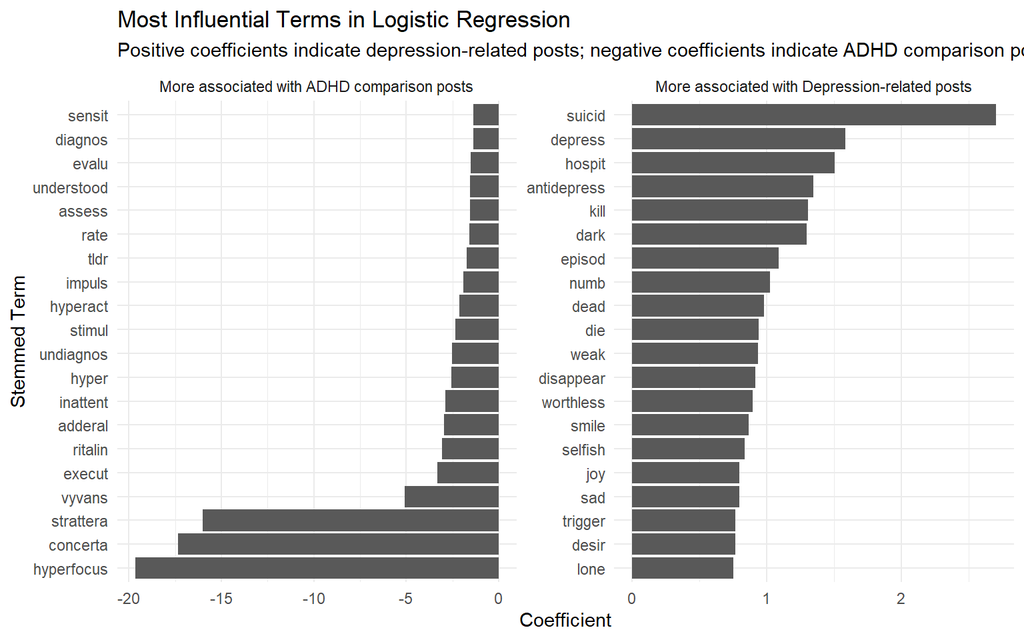

```r
coef_plot_data <- bind_rows(
  top_depression_terms,
  top_adhd_terms
)

p_coefficients <- ggplot(coef_plot_data, aes(
  x = reorder(term, coefficient),
  y = coefficient
)) +
  geom_col() +
  coord_flip() +
  facet_wrap(~ direction, scales = "free") +
  labs(
    title = "Most Influential Terms in Logistic Regression",
    subtitle = "Positive coefficients indicate depression-related posts; negative coefficients indicate ADHD comparison posts",
    x = "Stemmed Term",
    y = "Coefficient"
  ) +
  theme_minimal()

p_coefficients
```

```r
save_figure(
  p_coefficients,
  "logistic_regression_coefficients.png",
  width = 9,
  height = 5.5
)
```

The coefficient plot shows which terms contribute most strongly to the Logistic Regression model. This improves interpretability by making the model’s decision patterns more transparent. However, these terms should be interpreted carefully because Reddit community labels are not equivalent to clinical diagnoses.

## 9 Error Analysis and Limitations

Although Logistic Regression achieved strong overall performance, error analysis is important because this project is framed as an early-risk triage support system. False negatives may represent depression-related posts missed by the model, while false positives may increase the workload for human reviewers.

```r
# Create prediction result table for Logistic Regression
logistic_results <- data.frame(
  actual = test_y,
  predicted = logistic_pred,
  probability_depression = logistic_prob,
  word_count = test_data$word_count
)

logistic_results$error_type <- ifelse(
  logistic_results$actual == logistic_results$predicted,
  "Correct",
  ifelse(
    logistic_results$actual == "Depression" & logistic_results$predicted == "ADHD",
    "False Negative",
    "False Positive"
  )
)

# Error summary
error_summary <- logistic_results %>%
  count(error_type) %>%
  mutate(
    percentage = round(n / sum(n) * 100, 2)
  )

error_summary
```

```
##       error_type    n percentage
## 1        Correct 6188      90.24
## 2 False Negative  304       4.43
## 3 False Positive  365       5.32
```

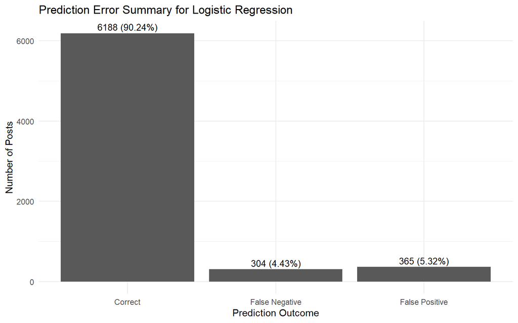

```r
p_error_summary <- ggplot(error_summary, aes(x = error_type, y = n)) +
  geom_col() +
  geom_text(
    aes(label = paste0(n, " (", percentage, "%)")),
    vjust = -0.4,
    size = 3.5
  ) +
  labs(
    title = "Prediction Error Summary for Logistic Regression",
    x = "Prediction Outcome",
    y = "Number of Posts"
  ) +
  theme_minimal()

p_error_summary
```

```r
save_figure(
  p_error_summary,
  "prediction_error_summary.png",
  width = 8,
  height = 5
)
```

```r
# Compare text length across prediction outcomes
error_length_summary <- logistic_results %>%
  group_by(error_type) %>%
  summarise(
    count = n(),
    median_word_count = median(word_count),
    mean_word_count = round(mean(word_count), 2),
    .groups = "drop"
  )

error_length_summary
```

```
## # A tibble: 3 × 4
##   error_type     count median_word_count mean_word_count
##   <chr>          <int>             <dbl>           <dbl>
## 1 Correct         6188              144             199.
## 2 False Negative   304              150.            236.
## 3 False Positive   365              131             164.
```

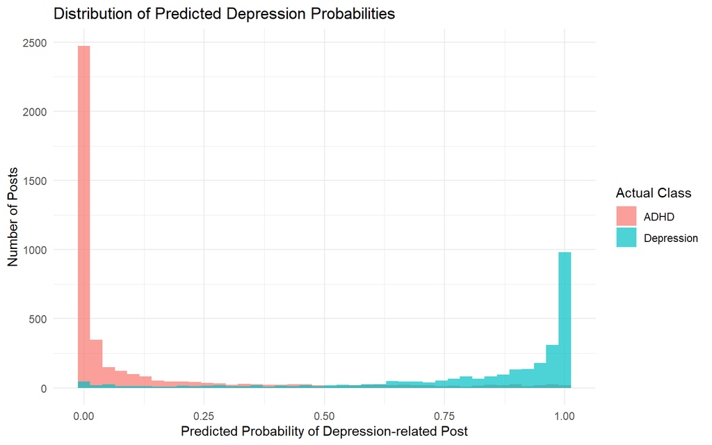

```r
p_probability_distribution <- ggplot(logistic_results, aes(x = probability_depression, fill = actual)) +
  geom_histogram(bins = 40, alpha = 0.7, position = "identity") +
  labs(
    title = "Distribution of Predicted Depression Probabilities",
    x = "Predicted Probability of Depression-related Post",
    y = "Number of Posts",
    fill = "Actual Class"
  ) +
  theme_minimal()

p_probability_distribution
```

```r
save_figure(
  p_probability_distribution,
  "predicted_depression_probability_distribution.png",
  width = 8,
  height = 5
)
```

The error analysis shows how many posts were correctly classified and how many were false positives or false negatives. In this project, false negatives are especially important because they represent depression-related posts that the model failed to identify. However, false positives are also important because they may create unnecessary workload in a human-review triage workflow. Therefore, the model should be used as decision support rather than as an automated diagnostic system.

## 10 Summary of Demonstration Findings

The R demonstration shows that Reddit mental health posts can be transformed into structured text features and used to classify depression-related posts against an ADHD comparison group. Exploratory analysis showed that the cleaned dataset contains 34,282 posts, with a moderate class imbalance between ADHD comparison posts and depression-related posts. Text length analysis showed that Reddit posts vary substantially in length, which supports the need for preprocessing and feature engineering.

Word frequency and TF-IDF analysis revealed different linguistic patterns across the two post categories. ADHD comparison posts were more strongly associated with medication, attention, diagnosis, and executive-function-related terms. Depression-related posts were more associated with emotional distress, social vulnerability, negative experiences, and risk-related language.

The modelling results showed that Logistic Regression achieved stronger overall performance than Naive Bayes, with higher accuracy, precision, F1-score, and AUC. Naive Bayes achieved slightly higher recall but produced more false positives. Logistic Regression was therefore selected as the main model because it provides both strong predictive performance and interpretable coefficients.

The coefficient analysis showed that the model learned meaningful term-level patterns. However, the results should not be interpreted as clinical diagnosis. The dataset is based on subreddit categories rather than verified clinical labels, and model outputs should only be used as decision-support signals in a human-reviewed early-risk triage workflow.

## 11 Save Outputs

This section saves key tables generated during the analysis into the project `results/tables` folder. These outputs make the project easier to reproduce, organise, and share as a portfolio project.

```r
# Helper function for saving tables only if the object exists
save_table_if_exists <- function(object_name, file_name) {
  if (exists(object_name)) {
    object_value <- get(object_name)

    write.csv(
      object_value,
      file.path(tables_dir, file_name),
      row.names = FALSE
    )

    return(data.frame(
      Object = object_name,
      File = file_name,
      Status = "Saved"
    ))
  } else {
    return(data.frame(
      Object = object_name,
      File = file_name,
      Status = "Object not found"
    ))
  }
}

# Save important analysis tables
saved_tables <- rbind(
  save_table_if_exists("cleaning_summary", "cleaning_summary.csv"),
  save_table_if_exists("class_distribution", "class_distribution.csv"),
  save_table_if_exists("text_length_summary", "text_length_summary.csv"),
  save_table_if_exists("top_words_by_class", "top_words_by_class.csv"),
  save_table_if_exists("top_tfidf_words_safe", "top_tfidf_words_safe.csv"),
  save_table_if_exists("feature_summary", "feature_summary.csv"),
  save_table_if_exists("model_comparison", "model_comparison.csv"),
  save_table_if_exists("auc_summary", "auc_summary.csv"),
  save_table_if_exists("error_summary", "error_summary.csv"),
  save_table_if_exists("error_length_summary", "error_length_summary.csv"),
  save_table_if_exists("top_depression_terms", "top_depression_terms.csv"),
  save_table_if_exists("top_adhd_terms", "top_adhd_terms.csv")
)

saved_tables
```

```
##                  Object                     File Status
## 1      cleaning_summary     cleaning_summary.csv  Saved
## 2    class_distribution   class_distribution.csv  Saved
## 3   text_length_summary  text_length_summary.csv  Saved
## 4    top_words_by_class   top_words_by_class.csv  Saved
## 5  top_tfidf_words_safe top_tfidf_words_safe.csv  Saved
## 6       feature_summary      feature_summary.csv  Saved
## 7      model_comparison     model_comparison.csv  Saved
## 8           auc_summary          auc_summary.csv  Saved
## 9         error_summary        error_summary.csv  Saved
## 10 error_length_summary error_length_summary.csv  Saved
## 11 top_depression_terms top_depression_terms.csv  Saved
## 12       top_adhd_terms       top_adhd_terms.csv  Saved
```

```r
saved_figures <- list.files(
  figures_dir,
  pattern = "\\.png$",
  full.names = FALSE
)

data.frame(
  Saved_Figures = saved_figures
)
```

```
##                                       Saved_Figures
## 1                            class_distribution.png
## 2              logistic_regression_coefficients.png
## 3                  model_performance_comparison.png
## 4 predicted_depression_probability_distribution.png
## 5                      prediction_error_summary.png
## 6                                    roc_curves.png
## 7                       text_length_log_boxplot.png
## 8                          tfidf_terms_by_class.png
## 9                            top_words_by_class.png
```

```r
# Save trained models and DTM dictionary for reproducibility
saveRDS(
  logistic_model,
  file.path(models_dir, "logistic_regression_model.rds")
)

saveRDS(
  nb_model,
  file.path(models_dir, "naive_bayes_model.rds")
)

saveRDS(
  dtm_dictionary,
  file.path(models_dir, "dtm_dictionary.rds")
)

saved_models <- list.files(
  models_dir,
  pattern = "\\.rds$",
  full.names = FALSE
)

data.frame(
  Saved_Models = saved_models
)
```

```
##                    Saved_Models
## 1            dtm_dictionary.rds
## 2 logistic_regression_model.rds
## 3         naive_bayes_model.rds
```